# RNA-seq differential gene expression

Uganda: TB-induced RSTR vs LTBI

Kim Dill-McFarland, kadm@uw.edu

version May 27, 2021

# Background

The purpose of this workflow is to identify TB-induced differentially expressed genes (DEG).

# Setup

Load packages

```r
# Data manipulation and figures
library(tidyverse)
    # Multi-panel figures for ggplot
    library(cowplot)
library(readxl)
library(venn)
# Genomic annotation
library(org.Hs.eg.db)
library(biomaRt)
#Gene ontology
library(topGO)
# Print tty table to knit file
library(knitr)
library(kableExtra)

`%notin%` <- Negate(`%in%`)
```

Set seed

```r
set.seed(4389)
```

# Customization

Set variable names and cutoffs for this workflow.

```r
#Rdata file WITHIN project directory that holds cleaned data
data.file <- "data_clean/RSTR_RNAseq_data_combined_uniqueFULLID.RData"

#Prefix to give file names
basename <- "RSTR.Mtb"
#Define variable(s) of interest
#Used in PCA plots and to select significant genes to be used in module building
vars_of_interest <- c("condition", "Sample_Group")
```

# Load data

```r
#Load data
attach(data.file)
```

Kinship data.

```r
kin <- read_csv("data_raw/kinship_Hawn_all.csv")

overlap <- intersect(kin$rowname, meta.combined$FULLIDNO)

kin <- kin %>%
  filter(rowname %in% overlap) %>%
  dplyr::select(rowname, all_of(overlap)) %>%
  arrange(rowname) %>%
  column_to_rownames()
```

Samples with RNA-seq and kinship.

```
## Note: Using an external vector in selections is ambiguous.
## ℹ Use `all_of(vars_of_interest)` instead of `vars_of_interest` to silence this message.
## ℹ See <https://tidyselect.r-lib.org/reference/faq-external-vector.html>.
```

| condition | Sample_Group | n |
| --- | --- | --- |
| MEDIA | LTBI | 49 |
| MEDIA | RSTR | 43 |
| TB | LTBI | 49 |
| TB | RSTR | 43 |

```r
#Rename for workflow
dat.voom <- dat.combined.voom
meta <- meta.combined
```

# Data exploration

## PCA (genes)

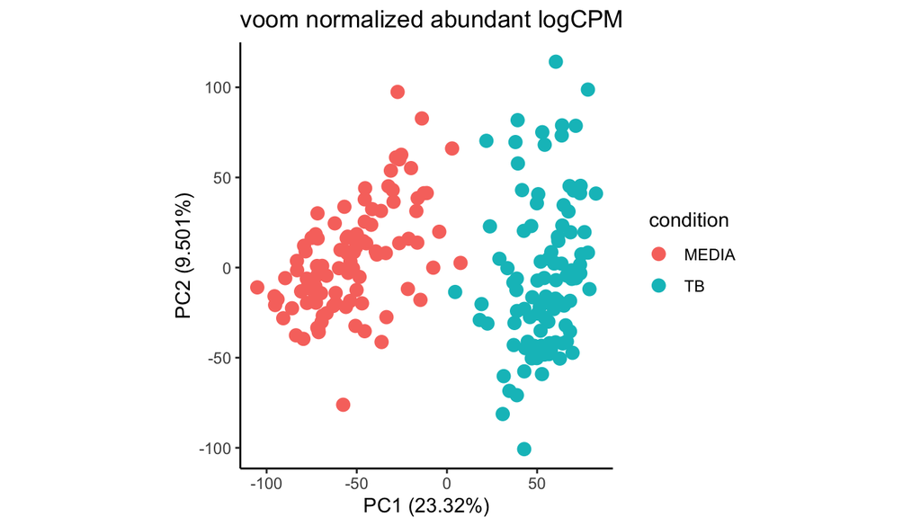

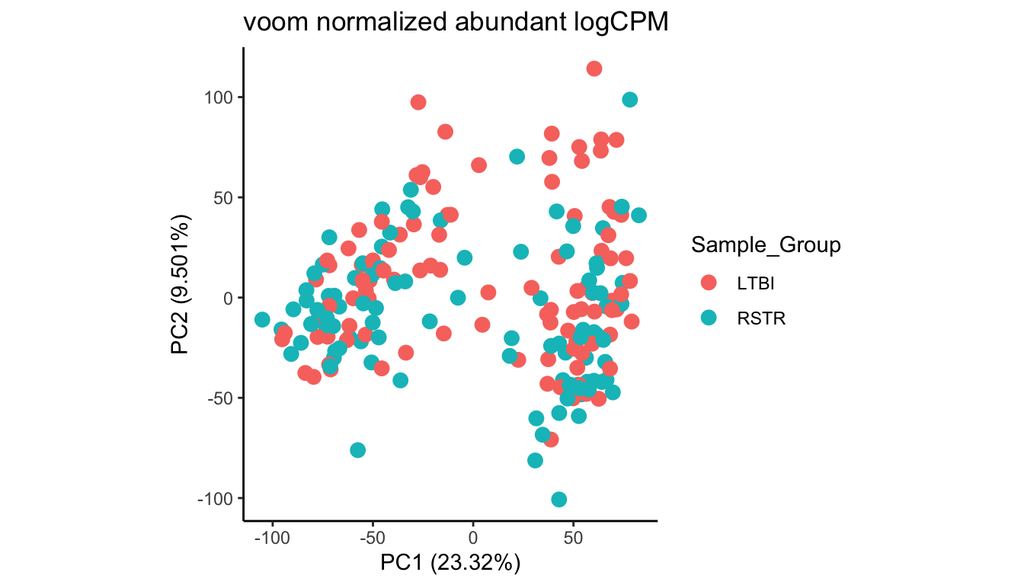

# Define significant genes

## Interaction linear model

For a comparison of model co-variates (age, sex, batch, kinship) and samples (all vs those with kinship), see RSTR RNA-seq model selection

```r
source("scripts/kin.model.fxn.R")
lmekin.loop(dat = dat.voom, kin = kin,
             x.var = c("condition","Sample_Group"), ptID="FULLIDNO",
             co.var=c("KCHCA_AGE_YR_CURRENT","M0_KCVSEX","experiment"),
             interaction=TRUE,
             lm=FALSE, lme=TRUE,
             outdir="results/gene_level/", name="RSTR.interaction_age.sex.batch",
             processors=5, p.method="BH")
```

```r
#load results
gene_pval <- read_csv("results/model_selection/RSTR.interaction_age.sex.batch.model.results.csv.gz") %>%
  filter(model=="lmekin")
```

Annotate genes locations.

```r
#Get reference genome
ensembl <- useMart("ensembl", dataset = "hsapiens_gene_ensembl",
                   host = "useast.ensembl.org")
  #Check genome version
  searchDatasets(mart = ensembl, pattern = "hsapiens")
```

```
##                  dataset              description    version
## 80 hsapiens_gene_ensembl Human genes (GRCh38.p13) GRCh38.p13
```

```r
#Get HGNC symbols and gene positions
gene.POS <- getBM(attributes = c('hgnc_symbol', 'ensembl_gene_id',
                                 'entrezgene_id',
                                 'chromosome_name',
                                'start_position','end_position',
                                'strand'),
      mart = ensembl) %>%
  #Rename
  dplyr::rename(CHR=chromosome_name, gene.strand = strand) %>%
  #Calculate max range of positions from multi-annotations
  filter(!grepl("CHR", CHR)) %>%
  group_by(CHR, hgnc_symbol, ensembl_gene_id, entrezgene_id,
           gene.strand) %>%
  summarise(min.start = min(start_position, na.rm=TRUE),
            max.end = max(end_position, na.rm=TRUE), .groups = "drop")
```

```r
# Match hgnc and ensembl names
genes <- dat.voom$genes %>%
  #Separate multi ensembl annotations
  mutate(geneName = gsub("^NA/","", geneName),
         geneName = gsub("/NA$","", geneName)) %>%
  separate(geneName, into=c("ensembl1", "ensembl2", "ensembl3",
                            "ensembl4"), sep="/") %>%
  dplyr::select(symbol:ensembl4) %>%
  #genes with model results
  filter(symbol %in% gene_pval$gene)

#Add positions based on any name
genes.anno <- genes %>%
  left_join(gene.POS, by=c("symbol"="hgnc_symbol")) %>%
  left_join(gene.POS, by=c("ensembl1"="ensembl_gene_id")) %>%
  left_join(gene.POS, by=c("ensembl2"="ensembl_gene_id")) %>%
  left_join(gene.POS, by=c("ensembl3"="ensembl_gene_id")) %>%
  left_join(gene.POS, by=c("ensembl4"="ensembl_gene_id")) %>%
  #keep 1 anno per gene
  mutate(CHR = ifelse(!is.na(CHR.x), CHR.x,
                      ifelse(!is.na(CHR.y), CHR.y,
                             ifelse(!is.na(CHR.x.x), CHR.x.x,
                                    ifelse(!is.na(CHR.y.y), CHR.y.y,
                                           CHR)))),
         start = ifelse(!is.na(min.start.x), min.start.x,
                      ifelse(!is.na(min.start.y), min.start.y,
                             ifelse(!is.na(min.start.x.x), min.start.x.x,
                                    ifelse(!is.na(min.start.y.y), min.start.y.y,
                                           min.start)))),
         end = ifelse(!is.na(max.end.x), max.end.x,
                      ifelse(!is.na(max.end.y), max.end.y,
                             ifelse(!is.na(max.end.x.x), max.end.x.x,
                                    ifelse(!is.na(max.end.y.y), max.end.y.y,
                                           max.end)))),
         ensembl_gene_id = ifelse(!is.na(CHR.x), ensembl1,
                      ifelse(!is.na(CHR.y), ensembl1,
                             ifelse(!is.na(CHR.x.x), ensembl2,
                                    ifelse(!is.na(CHR.y.y), ensembl3,
                                           ensembl4)))),
         entrezgene_id = ifelse(!is.na(CHR.x), entrezgene_id.x,
                      ifelse(!is.na(CHR.y), entrezgene_id.y,
                             ifelse(!is.na(CHR.x.x), entrezgene_id.x.x,
                                    ifelse(!is.na(CHR.y.y), entrezgene_id.y.y,
                                           entrezgene_id))))) %>%
  dplyr::select(symbol, ensembl_gene_id, entrezgene_id, CHR, start, end) %>%
  #add missing positions by hand
  drop_na(CHR) %>%
  bind_rows(data.frame(
    symbol = c("C4B_2","C9orf47","GSTT1","GTF2H2C_2","GVQW1",
               "HLA-DRB3","HLA-DRB4","KIAA0125","KIAA1107","LILRA3",
               "MICALCL","OCLM","PANO1","TCEB3CL"),
    ensembl_gene_id = c(NA,"ENSG00000213694",NA,NA,"ENSG00000241043.1",
                        NA,NA,"ENSG00000226777",NA,NA,
                        "ENSG00000133816",NA,"ENSG00000274897","ENSG00000278674"),
    CHR = as.character(c(6,9,22,5,9,
            6,6,14,1,19,
            11,1,11,18)),
    start = c(3283246,88990863,270308,965642, 32566789,
              3715355,3851133,105917978,92168921,270964,
              12094008,186400578,796633,47022287),
    end = c(3303870,89005155,278486,997938,32568621,
            3728422,3866104,105932642,92188509,275379,
            12362140,186401449,799185,47023927)
  )) %>%
  #collapse multi entrez
  group_by(symbol, ensembl_gene_id, CHR, start, end) %>%
  summarise(entrezgene_id = paste(unique(entrezgene_id[!is.na(entrezgene_id)]),
                                  collapse="/"),
            .groups="drop")

left_join(gene_pval, genes.anno, by=c("gene"="symbol")) %>%
  write_csv(file="results/gene_level/RSTR.Mtb.model.results.anno.csv")
```

### Significant genes

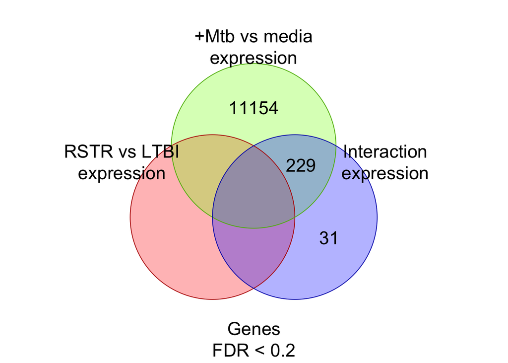

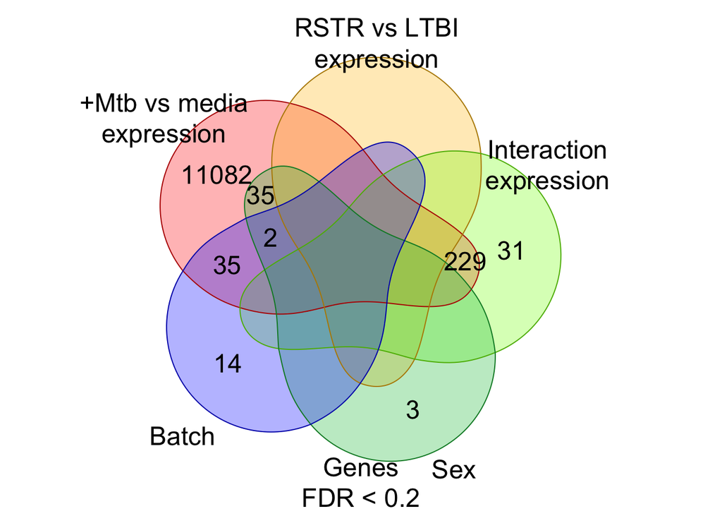

## Contrasts linear model

Interaction term significant genes will be further assessed in pairwise comparisons within Mtb and RSTR groups (*e.g.* contrasts). Since no genes were significant for the main term RSTR, no further modeling is needed for this term.

```r
source("scripts/kin.model.fxn.R")
lmekin.loop(dat = dat.voom, kin = kin,
             x.var = c("Sample_Group"), ptID="FULLIDNO",
             co.var=c("KCHCA_AGE_YR_CURRENT","M0_KCVSEX","experiment"),
             interaction=TRUE,
             lm=FALSE, lme=FALSE,
             subset.var = "condition", subset.lvl = "MEDIA",
             subset.genes = venn.ls[["Interaction\nexpression"]],
             outdir="results/gene_level/", name=paste(basename, "media", sep="."),
             processors=5, p.method="BH")

lmekin.loop(dat = dat.voom, kin = kin,
             x.var = c("Sample_Group"), ptID="FULLIDNO",
             co.var=c("KCHCA_AGE_YR_CURRENT","M0_KCVSEX","experiment"),
             interaction=TRUE,
             lm=FALSE, lme=FALSE,
             subset.var = "condition", subset.lvl = "TB",
             subset.genes = venn.ls[["Interaction\nexpression"]],
             outdir="results/gene_level/", name=paste(basename, "tb", sep="."),
             processors=5, p.method="BH")

lmekin.loop(dat = dat.voom, kin = kin,
             x.var = c("condition"), ptID="FULLIDNO",
             co.var=c("KCHCA_AGE_YR_CURRENT","M0_KCVSEX","experiment"),
             interaction=TRUE,
             lm=FALSE, lme=FALSE,
             subset.var = "Sample_Group", subset.lvl = "RSTR",
             subset.genes = venn.ls[["Interaction\nexpression"]],
             outdir="results/gene_level/", name=paste(basename, "rstr", sep="."),
             processors=5, p.method="BH")

lmekin.loop(dat = dat.voom, kin = kin,
             x.var = c("condition"), ptID="FULLIDNO",
             co.var=c("KCHCA_AGE_YR_CURRENT","M0_KCVSEX","experiment"),
             interaction=TRUE,
             lm=FALSE, lme=FALSE,
             subset.var = "Sample_Group", subset.lvl = "LTBI",
             subset.genes = venn.ls[["Interaction\nexpression"]],
             outdir="results/gene_level/", name=paste(basename, "ltbi", sep="."),
             processors=5, p.method="BH")
```

### Significant genes

```r
contrast_pval <- read_csv("results/gene_level/RSTR.Mtb.media.model.results.csv.gz") %>%
  bind_rows(read_csv("results/gene_level/RSTR.Mtb.tb.model.results.csv.gz")) %>%
  bind_rows(read_csv("results/gene_level/RSTR.Mtb.ltbi.model.results.csv.gz")) %>%
  bind_rows(read_csv("results/gene_level/RSTR.Mtb.rstr.model.results.csv.gz"))
```

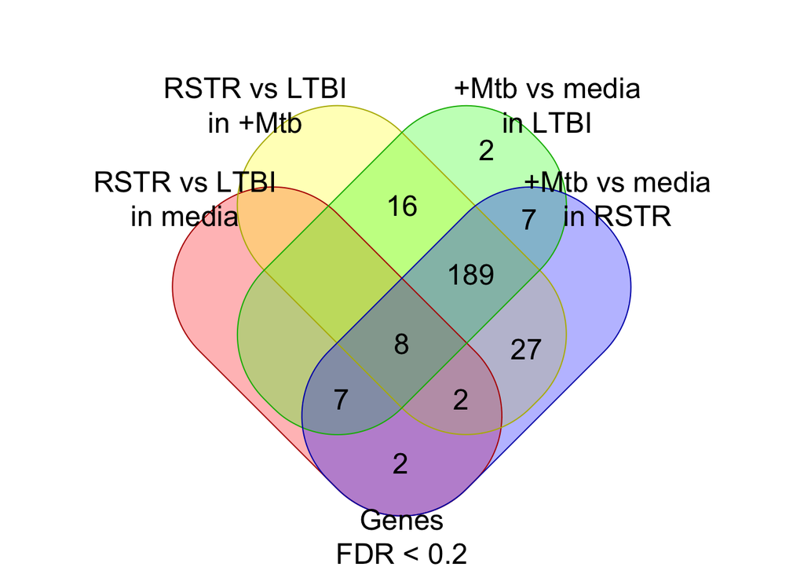

## Gene plots

Interaction term DEGs are in `figs/gene_level`

```r
source("https://raw.githubusercontent.com/kdillmcfarland/R_bioinformatic_scripts/master/RNAseq_boxplot_fxn.R")

pval.toPlot <- contrast_pval %>%
  filter(variable %in% c("Sample_GroupRSTR", "conditionTB")) %>%
  dplyr::rename(adj.P.Val=FDR, dataset=group) %>%
  mutate(group = paste(dataset, variable, sep="."),
         group = recode(group,
                        "RSTR.Mtb.media.Sample_GroupRSTR"="RSTR.in.MEDIA",
                        "RSTR.Mtb.tb.Sample_GroupRSTR"="RSTR.in.TB",
                        "RSTR.Mtb.ltbi.conditionTB"="TB.in.LTBI",
                        "RSTR.Mtb.rstr.conditionTB"="TB.in.RSTR")) %>%
  select(gene, group, adj.P.Val)

plot.all(voom.dat = dat.voom,
         pval.dat = pval.toPlot,
         join.var = "libID",
         genes.toPlot = unique(unlist(venn.ls, use.names = FALSE)),
         vars = c("condition","Sample_Group"),
         var.levels=c("RSTR.in.MEDIA","RSTR.in.TB","TB.in.LTBI","TB.in.RSTR"),
         interaction=TRUE, color.var="Sample_Group",
         outdir="figs/gene_level/", name="RSTR_TB.DEG_",
         cores=2, width=6, height=10)
```

# Gene set enrichment analysis (GSEA)

```r
#Script for running GSEA
source("https://raw.githubusercontent.com/kdillmcfarland/R_bioinformatic_scripts/master/GSEA_fxn.R")
```

### Gene set descriptions

- Hallmark gene sets (H)
  - Hallmark gene sets summarize and represent specific well-defined biological states or processes and display coherent expression. These gene sets were generated by a computational methodology based on identifying overlaps between gene sets in other MSigDB collections and retaining genes that display coordinate expression.
- Basic gene sets (C5)
  - Gene sets that contain genes annotated by the same GO term. Includes:
  - BP: biological process
  - CC: cellular component
  - MF: molecular function
- Curated gene sets (C2)
  - Gene sets curated from various sources including online pathway databases, the biomedical literature, and knowledge of domain experts. Includes:
  - CGP: chemical and genetic perturbations
  - CP: Canonical pathways
    - BIOCARTA: BioCarta gene sets
    - KEGG: KEGG gene sets
    - PID: PID gene sets
    - REACTOME: Reactome gene sets

### Calculate fold change

```r
TB.FC <- dat.combined.voom$E %>%
  rownames_to_column("hgnc_symbol") %>%
  pivot_longer(-hgnc_symbol) %>%
  full_join(dat.combined.voom$targets, by=c("name"="libID")) %>%
  dplyr::select(RSID, condition, Sample_Group, hgnc_symbol, value) %>%
  pivot_wider(names_from=condition) %>%
  mutate(FC = TB-MEDIA) %>%
  group_by(hgnc_symbol, Sample_Group) %>%
  dplyr::summarise(mean.FC = mean(FC, na.rm=TRUE)) %>%
  pivot_wider(names_from = Sample_Group, values_from = mean.FC)

RSTR.FC <- dat.combined.voom$E %>%
  rownames_to_column("hgnc_symbol") %>%
  pivot_longer(-hgnc_symbol) %>%
  full_join(dat.combined.voom$targets, by=c("name"="libID")) %>%
  dplyr::select(RSID, condition, Sample_Group, hgnc_symbol, value) %>%
  group_by(condition, Sample_Group, hgnc_symbol) %>%
  dplyr::summarise(mean.E = mean(value, na.rm=TRUE)) %>%
  pivot_wider(names_from=Sample_Group, values_from = mean.E) %>%
  mutate(FC = RSTR-LTBI) %>%
  group_by(hgnc_symbol, condition) %>%
  dplyr::summarise(mean.FC = mean(FC, na.rm=TRUE)) %>%
  pivot_wider(names_from = condition, values_from = mean.FC)

FC.all <- full_join(TB.FC, RSTR.FC, by = "hgnc_symbol")
```

```r
#Format for GSEA function
FC.ls <- list()

genes.temp <- FC.all$LTBI
  names(genes.temp) <- FC.all$hgnc_symbol
FC.ls[["TBinLTBI"]] <- genes.temp

genes.temp <- FC.all$RSTR
  names(genes.temp) <- FC.all$hgnc_symbol
FC.ls[["TBinRSTR"]] <- genes.temp

genes.temp <- FC.all$MEDIA
  names(genes.temp) <- FC.all$hgnc_symbol
FC.ls[["RSTRinMEDIA"]] <- genes.temp

genes.temp <- FC.all$TB
  names(genes.temp) <- FC.all$hgnc_symbol
FC.ls[["RSTRinTB"]] <- genes.temp
```

### Run GSEA

#### Hallmark (H)

```r
GSEA(gene_list = FC.ls, nperm=100000,
     outdir="results/GSEA/", plotdir="figs/GSEA/",
     gmt_file="data_clean/Broad.gene.sets/h.all.v7.2.symbols.gmt",
     plot = TRUE, plot.fdr = 0.1,
     plot.groups = list(c("TBinLTBI","TBinRSTR"),
                        c("RSTRinMEDIA","RSTRinTB")))
```

#### Curated gene sets (C2 CP)

```r
GSEA(gene_list = FC.ls, nperm=100000,
     outdir="results/GSEA/", plotdir="figs/GSEA/",
     gmt_file="data_clean/Broad.gene.sets/c2.cp.v7.2.symbols.gmt",
     plot = TRUE, plot.fdr = 0.1,
     plot.groups = list(c("TBinLTBI","TBinRSTR"),
                        c("RSTRinMEDIA","RSTRinTB")))
```

#### Basic gene sets (C5)

```r
GSEA(gene_list = FC.ls, nperm=100000,
     outdir="results/GSEA/", plotdir="figs/GSEA/",
     gmt_file="data_clean/Broad.gene.sets/c5.go.v7.2.symbols.gmt",
     plot = TRUE, plot.fdr = 0.1,
     plot.groups = list(c("TBinLTBI","TBinRSTR"),
                        c("RSTRinMEDIA","RSTRinTB")))
```

#### Xue et al modules

```r
#load genes in modules from Xue et al
library(readxl)
xue <- read_excel("data_raw/Xue/mmc3.xlsx", sheet="Table S2B", skip=3) %>%
  pivot_longer(-Genes, values_to = "symbol") %>%
  mutate(module=ifelse(as.numeric(name) <= 9,
                       paste("0", name, sep=""),name),
         module=paste("module", module, sep="_")) %>%
  dplyr::select(module, symbol) %>%
  drop_na(symbol)

#format to list like Broad GMT
xue.ls <- list()

for(mod in unique(xue$module)){
  temp <- xue %>%
    filter(module == mod) %>%
    distinct(symbol) %>% unlist(use.names = FALSE)
  xue.ls[[mod]] <- temp
}
```

```r
GSEA(gene_list = FC.ls, nperm=100000,
     outdir="results/GSEA/", plotdir="figs/GSEA/",
     gmt_ls=xue.ls, name="Xue.modules",
     plot = TRUE, plot.fdr = 0.1,
     plot.groups = list(c("TBinLTBI","TBinRSTR"),
                        c("RSTRinMEDIA","RSTRinTB")))
```

#### GSEA summary

FDR < 0.1 for RSTR vs LTBI in media and/or +Mtb **AND** for Mtb in RSTR and/or LTBI

| Gene set | Terms FDR < 0.1 for both TB and RSTR |
| --- | --- |
| C2 | 101 |
| C5 | 269 |
| H | 23 |
| Xue | 10 |

Additional heatmap for significant Xue modules

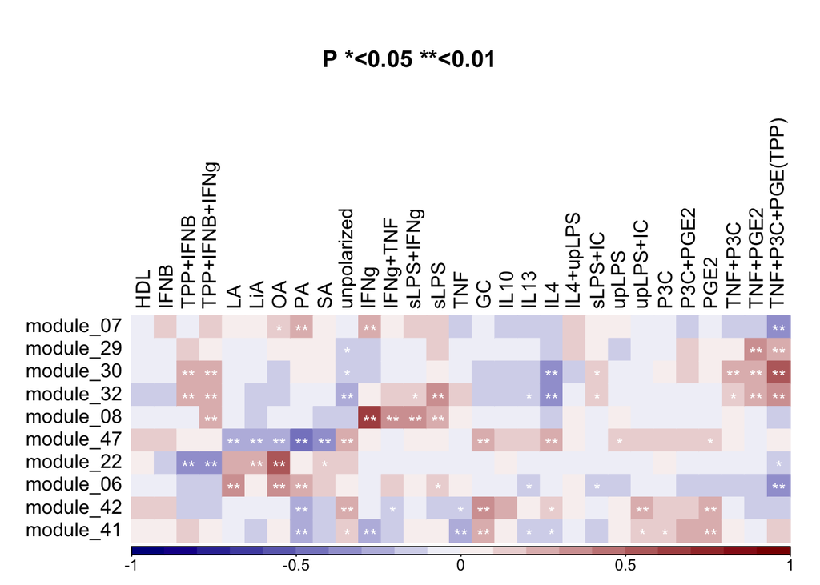

# Gene ontology (GO)

Determine GO gene set enrichment in overall DEG lists as well as STRING network clusters

## All DEG

```r
genes <- gene_pval %>%
  filter(model=="lmekin" & variable == "conditionTB:Sample_GroupRSTR") %>%
  distinct(gene, FDR)

DEG <- genes %>%
  filter(FDR <= fdr.cutoff) %>%
  distinct(gene) %>% unlist(use.names = FALSE)
```

```r
#Format to named vector
genes.vec <- genes %>%
  mutate(group = ifelse(gene %in% DEG, 1, 0),
         group = factor(group)) %>%
  dplyr::select(group) %>% unlist(use.names=FALSE)
names(genes.vec) <- genes$gene

#Make topGO object
GOdata <- new("topGOdata", ontology = "BP",
               allGenes = genes.vec,
               annot = annFUN.org, mapping="org.Hs.eg.db", ID = "symbol",
               nodeSize = 1)
```

```
##
## Building most specific GOs .....
```

```
##  ( 11036 GO terms found. )
```

```
##
## Build GO DAG topology ..........
```

```
##  ( 15013 GO terms and 35480 relations. )
```

```
##
## Annotating nodes ...............
```

```
##  ( 12150 genes annotated to the GO terms. )
```

```r
#Test enrichment of terms
test.stat <- new("classicCount", testStatistic = GOFisherTest, name = "Fisher test")
resultFisher <- getSigGroups(GOdata, test.stat)
```

```
##
##           -- Classic Algorithm --
##
##       the algorithm is scoring 4429 nontrivial nodes
##       parameters:
##           test statistic: Fisher test
```

```r
#Plot
#Determine # of signif nodes to plot
enrichFDR <- p.adjust(score(resultFisher), method="fdr")

node.signif <- sum(enrichFDR <= 0.2)
dir.create("figs/topGO", showWarnings = FALSE)
pdf("figs/topGO/DEG.FDR0.2.pdf",height=10, width=10)
showSigOfNodes(GOdata, termsP.value=enrichFDR,
               firstSigNodes = node.signif, useInfo = 'all')
```

```
## $dag
## A graphNEL graph with directed edges
## Number of Nodes = 35
## Number of Edges = 53
##
## $complete.dag
## [1] "A graph with 35 nodes."
```

```r
dev.off()
```

## STRING clusters

List genes in clusters $\geq$ 3 genes

```r
#DEGs in cluster
lrg <- c("CLNS1A","GEMIN5","GEMIN6","POLDIP3","SARNP","NUP210","HDAC6",
                   "PHC2","SUMO1","EGFL8","GPSM3","GPR18",
                   "P2RY13","CXCL9","EBF1","ZBTB17","IRF8",
                   "FCGR1A","FCGR1B","CIITA","IRF1","IFNG",
                   "ANPEP","SMARCB1","CSF1R","IL2",
                   "RASGRP1","GRB2","GAB2","PIK3CD","VAV2",
                   "AKT1","LIMS1","ARAF","PPP2R3C","PPP2CA",
                   "TJP1","KIFC3","CTNNB1","AKT3","FOXO3",
                   "CRTC2","TNFRSF1B","IKBKB","RAB3C","RAB5A",
                   "RUFY1","DENND1C","RAB13","EXOC8","LEPROTL1",
                   "C2CD5","ARAP1","AKAP13","AKAP1","KDELR1","TRAF3",
                   "GNA12","NFKBIE","TNFAIP3","FCAR","TIMP1",
                   "COPB1","TBK1","FCAMR","PEF1","TBKBP1",
                   "CHST7","ADAMTS1","CYB5R3","VCAN","DNAJC3",
                   "CST3","CFP","CANT1","UMPS","MTHFR")

med <- c("YTHDC2","MYBBP1A","DDX10","URB1","NOP56",
          "WDR3","RRP15","CIRH1A","DDX51","NOL8")

sm1<- c("CUL3","RNF6","FBXO4","NEDD4","ZNRF2")
sm2 <- c("HS3ST1","GCNT1","ST3GAL1","ST3GAL2","B4GALT1")
sm3 <- c("USB1","SYF2","SF3A3","HNRNPM","CD2BP2")
sm4 <- c("CEP164","TUBGCP6","MARK4")
```

```r
for(cluster in c("lrg","med","sm1","sm2","sm3","sm4")){
  #Format to named vector
genes.vec <- genes %>%
  mutate(group = ifelse(gene %in% get(cluster), 1, 0),
         group = factor(group)) %>%
  dplyr::select(group) %>% unlist(use.names=FALSE)
names(genes.vec) <- genes$gene

#Make topGO object
GOdata <- new("topGOdata", ontology = "BP",
               allGenes = genes.vec,
               annot = annFUN.org, mapping="org.Hs.eg.db", ID = "symbol",
               nodeSize = 1)

#Test enrichment of terms
test.stat <- new("classicCount", testStatistic = GOFisherTest, name = "Fisher test")
resultFisher <- getSigGroups(GOdata, test.stat)

#Plot
#Determine # of signif nodes to plot
enrichFDR <- p.adjust(score(resultFisher), method="fdr")

node.signif <- sum(enrichFDR <= 0.05)
dir.create("figs/topGO", showWarnings = FALSE)
pdf(paste("figs/topGO/DEG.cluster",cluster, "FDR0.05.pdf", sep="."),
    height=10, width=10)
showSigOfNodes(GOdata, termsP.value=enrichFDR,
               firstSigNodes = node.signif, useInfo = 'all')
dev.off()
}
```